# COGS 108 - Final Project (change this to your project's title)

### Household Income

```python
# Uncleaned data for household income

# To start, we had to edit the original excel file a bit to get to fit as csv.
# This includes removing the text description at the start and removing all of the
# data for other types of households that we did not need.
# The only data we wanted was the data for all households.

# This data had garbage values for the column names and also garbage values in the first two rows.
# Some of the years have values in parenthesis after them, which we wanted to get rid of.
# We decided to work on the median over the mean, so we had to convert it to int.
# Also, some years are repeated for some reason, so we needed to remove the duplicates and find the
# average for those years
df_income = pd.read_csv('h09ar.csv');
df_income
```

|  | All Households | Unnamed: 1 | Unnamed: 2 | Unnamed: 3 | Unnamed: 4 | Unnamed: 5 |
| --- | --- | --- | --- | --- | --- | --- |
| 0 | Type of household\nand year | Number (thousands) | Median income | NaN | Mean income | NaN |
| 1 | NaN | NaN | Current\ndollars | 2020\ndollars | Current\ndollars | 2020\ndollars |
| 2 | 2020 | 129,931 | 67,521 | 67,521 | 97,026 | 97,026 |
| 3 | 2019 | 128,451 | 68,703 | 69,560 | 98,088 | 99,312 |
| 4 | 2018 | 128,579 | 63,179 | 65,127 | 90,021 | 92,796 |
| 5 | 2017 (40) | 127,669 | 61,136 | 64,557 | 87,643 | 92,547 |
| 6 | 2017 | 127,586 | 61,372 | 64,806 | 86,220 | 91,044 |
| 7 | 2016 | 126,224 | 59,039 | 63,683 | 83,143 | 89,683 |
| 8 | 2015 | 125,819 | 56,516 | 61,748 | 79,263 | 86,601 |
| 9 | 2014 | 124,587 | 53,657 | 58,725 | 75,738 | 82,892 |
| 10 | 2013 (39) | 123,931 | 53,585 | 59,640 | 75,195 | 83,691 |
| 11 | 2013 (38) | 122,952 | 51,939 | 57,808 | 72,641 | 80,849 |
| 12 | 2012 | 122,459 | 51,017 | 57,623 | 71,274 | 80,503 |
| 13 | 2011 | 121,084 | 50,054 | 57,732 | 69,677 | 80,366 |
| 14 | 2010 (37) | 119,927 | 49,276 | 58,627 | 67,392 | 80,180 |
| 15 | 2009 (36) | 117,538 | 49,777 | 60,200 | 67,976 | 82,210 |
| 16 | 2008 | 117,181 | 50,303 | 60,624 | 68,424 | 82,464 |
| 17 | 2007 | 116,783 | 50,233 | 62,865 | 67,609 | 84,611 |
| 18 | 2006 | 116,011 | 48,201 | 62,033 | 66,570 | 85,673 |
| 19 | 2005 | 114,384 | 46,326 | 61,553 | 63,344 | 84,164 |
| 20 | 2004 (35) | 113,343 | 44,334 | 60,901 | 60,466 | 83,062 |
| 21 | 2003 | 112,000 | 43,318 | 61,113 | 59,067 | 83,332 |
| 22 | 2002 | 111,278 | 42,409 | 61,190 | 57,852 | 83,472 |
| 23 | 2001 | 109,297 | 42,228 | 61,889 | 58,208 | 85,309 |
| 24 | 2000 (30) | 108,209 | 41,990 | 63,292 | 57,135 | 86,120 |
| 25 | 1999 (29) | 106,434 | 40,696 | 63,423 | 54,737 | 85,306 |
| 26 | 1998 | 103,874 | 38,885 | 61,891 | 51,855 | 82,535 |
| 27 | 1997 | 102,528 | 37,005 | 59,697 | 49,692 | 80,163 |
| 28 | 1996 | 101,018 | 35,492 | 58,494 | 47,123 | 77,662 |
| 29 | 1995 (25) | 99,627 | 34,076 | 57,655 | 44,938 | 76,034 |
| 30 | 1994 (24) | 98,990 | 32,264 | 55,905 | 43,133 | 74,738 |
| 31 | 1993 (23) | 97,107 | 31,241 | 55,263 | 41,428 | 73,282 |
| 32 | 1992 (22) | 96,426 | 30,636 | 55,559 | 38,840 | 70,437 |
| 33 | 1991 | 95,669 | 30,126 | 55,992 | 37,922 | 70,482 |
| 34 | 1990 | 94,312 | 29,943 | 57,677 | 37,403 | 72,047 |
| 35 | 1989 | 93,347 | 28,906 | 58,425 | 36,520 | 73,815 |
| 36 | 1988 | 92,830 | 27,225 | 57,433 | 34,017 | 71,761 |
| 37 | 1987 (21) | 91,124 | 26,061 | 56,964 | 32,410 | 70,841 |
| 38 | 1986 | 89,479 | 24,897 | 56,291 | 30,759 | 69,545 |
| 39 | 1985 (20) | 88,458 | 23,618 | 54,334 | 29,066 | 66,868 |
| 40 | 1984 (19) | 86,789 | 22,415 | 53,337 | 27,464 | 65,351 |
| 41 | 1983 | 85,407 | 20,885 | 51,764 | 25,401 | 62,957 |
| 42 | 1982 | 83,918 | 20,171 | 52,130 | 24,309 | 62,824 |
| 43 | 1981 | 83,527 | 19,074 | 52,272 | 22,787 | 62,447 |
| 44 | 1980 | 82,368 | 17,710 | 53,116 | 21,063 | 63,172 |

```python
# Function used to clean up the years column in the household income dataset
# It is very much brute force because all the numbers in the parenthesis are different
def remove_parens(str_in):
    str_in = str_in.strip()
    try:
        str_in = str_in.replace('(', '')
        str_in = str_in.replace(')', '')
        if '40' in str_in:
            str_in = str_in.replace('40', '')
        if '39' in str_in:
            str_in = str_in.replace('39', '')
        if '38' in str_in:
            str_in = str_in.replace('38', '')
        if '37' in str_in:
            str_in = str_in.replace('37', '')
        if '36' in str_in:
            str_in = str_in.replace('36', '')
        if '35' in str_in:
            str_in = str_in.replace('35', '')
        if '30' in str_in:
            str_in = str_in.replace('30', '')
        if '29' in str_in:
            str_in = str_in.replace('29', '')
        if '25' in str_in:
            str_in = str_in.replace('25', '')
        if '24' in str_in:
            str_in = str_in.replace('24', '')
        if '23' in str_in:
            str_in = str_in.replace('23', '')
        if '22' in str_in:
            str_in = str_in.replace('22', '')

        # different format for these so I don't break the 20__ and 19__ years
        if '1987 21' in str_in:
            str_in = str_in.replace('1987 21', '1987')
        if '1985 20' in str_in:
            str_in = str_in.replace('1985 20', '1985')
        if '1984 19' in str_in:
            str_in = str_in.replace('1984 19', '1984')
        output = str_in
        output = output.strip()
    except:
        output = np.nan
    return output
```

```python
# Cleaning data for household income
df_income = pd.read_csv('h09ar.csv');

# Rename columns to get the correct column names for each column
df_income = df_income.rename(columns={'All Households': 'Year', 'Unnamed: 1': 'Number (thousands)',
                          'Unnamed: 2': 'Median (current dollars)', 'Unnamed: 3': 'Median (2020 dollars)',
                         'Unnamed: 4': 'Mean (current dollars)', 'Unnamed: 5': 'Mean (2020 dollars)'})

# Remove the top two rows because they are garbage values and reset index
df_income = df_income.iloc[2:]
df_income = df_income.reset_index(drop=True)

# We will use only the year and median household income
# We chose to use median income instead of mean because it is more representative
# of the general populace
df_income = df_income.filter(['Year', 'Median (2020 dollars)'])
df_income = df_income.rename(columns={'Median (2020 dollars)': 'median'}) # easier name to use

# Used previously defined functions to remove the weird parenthesis numbers in the year column
# And to convert the median value to int
df_income['Year'] = df_income['Year'].apply(remove_parens)
df_income['median'] = df_income['median'].apply(convert_int)

# There are duplicate rows for years 2013 and 2017, so
# we decided to average the two medians together for each.
mean2013 = df_income[df_income['Year'] == '2013']
mean2013 = mean2013['median'].mean()
mean2017 = df_income[df_income['Year'] == '2017']
mean2017 = mean2017['median'].mean()

# Drop the duplicate row for 2013 and 2017
df_income = df_income.drop_duplicates(subset=['Year'])

# Update the median value in the table to the average
i = df_income[df_income['Year'] == '2013'].index
df_income.loc[i, 'median'] = mean2013
i = df_income[df_income['Year'] == '2017'].index
df_income.loc[i, 'median'] = mean2017

# Reverse dataframe so earlier years come first and reset index to fix indices
df_income = df_income[::-1]
df_income = df_income.reset_index(drop=True)
df_income
```

|  | Year | median |
| --- | --- | --- |
| 0 | 1980 | 53116.0 |
| 1 | 1981 | 52272.0 |
| 2 | 1982 | 52130.0 |
| 3 | 1983 | 51764.0 |
| 4 | 1984 | 53337.0 |
| 5 | 1985 | 54334.0 |
| 6 | 1986 | 56291.0 |
| 7 | 1987 | 56964.0 |
| 8 | 1988 | 57433.0 |
| 9 | 1989 | 58425.0 |
| 10 | 1990 | 57677.0 |
| 11 | 1991 | 55992.0 |
| 12 | 1992 | 55559.0 |
| 13 | 1993 | 55263.0 |
| 14 | 1994 | 55905.0 |
| 15 | 1995 | 57655.0 |
| 16 | 1996 | 58494.0 |
| 17 | 1997 | 59697.0 |
| 18 | 1998 | 61891.0 |
| 19 | 1999 | 63423.0 |
| 20 | 2000 | 63292.0 |
| 21 | 2001 | 61889.0 |
| 22 | 2002 | 61190.0 |
| 23 | 2003 | 61113.0 |
| 24 | 2004 | 60901.0 |
| 25 | 2005 | 61553.0 |
| 26 | 2006 | 62033.0 |
| 27 | 2007 | 62865.0 |
| 28 | 2008 | 60624.0 |
| 29 | 2009 | 60200.0 |
| 30 | 2010 | 58627.0 |
| 31 | 2011 | 57732.0 |
| 32 | 2012 | 57623.0 |
| 33 | 2013 | 58724.0 |
| 34 | 2014 | 58725.0 |
| 35 | 2015 | 61748.0 |
| 36 | 2016 | 63683.0 |
| 37 | 2017 | 64681.5 |
| 38 | 2018 | 65127.0 |
| 39 | 2019 | 69560.0 |
| 40 | 2020 | 67521.0 |

### Unemployment Rate

```python
# Uncleaned data for unemployment rate

# This one was rather easy to clean up; all we had to do was average the unemployment rates
# for each month to get a rate for the entire year.
# We can also remove 2022 because it is incomplete.
df_unemployment = pd.read_csv('SeriesReport-20220210225524_383fc1.csv')
df_unemployment
```

|  | Year | Jan | Feb | Mar | Apr | May | Jun | Jul | Aug | Sep | Oct | Nov | Dec |
| --- | --- | --- | --- | --- | --- | --- | --- | --- | --- | --- | --- | --- | --- |
| 0 | 1948 | 3.4 | 3.8 | 4.0 | 3.9 | 3.5 | 3.6 | 3.6 | 3.9 | 3.8 | 3.7 | 3.8 | 4.0 |
| 1 | 1949 | 4.3 | 4.7 | 5.0 | 5.3 | 6.1 | 6.2 | 6.7 | 6.8 | 6.6 | 7.9 | 6.4 | 6.6 |
| 2 | 1950 | 6.5 | 6.4 | 6.3 | 5.8 | 5.5 | 5.4 | 5.0 | 4.5 | 4.4 | 4.2 | 4.2 | 4.3 |
| 3 | 1951 | 3.7 | 3.4 | 3.4 | 3.1 | 3.0 | 3.2 | 3.1 | 3.1 | 3.3 | 3.5 | 3.5 | 3.1 |
| 4 | 1952 | 3.2 | 3.1 | 2.9 | 2.9 | 3.0 | 3.0 | 3.2 | 3.4 | 3.1 | 3.0 | 2.8 | 2.7 |
| ... | ... | ... | ... | ... | ... | ... | ... | ... | ... | ... | ... | ... | ... |
| 70 | 2018 | 4.0 | 4.1 | 4.0 | 4.0 | 3.8 | 4.0 | 3.8 | 3.8 | 3.7 | 3.8 | 3.8 | 3.9 |
| 71 | 2019 | 4.0 | 3.8 | 3.8 | 3.6 | 3.6 | 3.6 | 3.7 | 3.7 | 3.5 | 3.6 | 3.6 | 3.6 |
| 72 | 2020 | 3.5 | 3.5 | 4.4 | 14.7 | 13.2 | 11.0 | 10.2 | 8.4 | 7.9 | 6.9 | 6.7 | 6.7 |
| 73 | 2021 | 6.4 | 6.2 | 6.0 | 6.0 | 5.8 | 5.9 | 5.4 | 5.2 | 4.7 | 4.6 | 4.2 | 3.9 |
| 74 | 2022 | 4.0 | NaN | NaN | NaN | NaN | NaN | NaN | NaN | NaN | NaN | NaN | NaN |

75 rows × 13 columns

```python
# Cleaning data for unemployment rate
df_unemployment = pd.read_csv('SeriesReport-20220210225524_383fc1.csv')

# Get average of the unemployment rates for each year
df_unemployment['avg'] = df_unemployment.loc[:, df_unemployment.columns!='Year'].mean(axis=1)

# We only want a table with year and yearly average unemployment rate
df_unemployment = df_unemployment.filter(['Year', 'avg'])

# Remove 2022
df_unemployment = df_unemployment.iloc[:-1]
df_unemployment
```

|  | Year | avg |
| --- | --- | --- |
| 0 | 1948 | 3.750000 |
| 1 | 1949 | 6.050000 |
| 2 | 1950 | 5.208333 |
| 3 | 1951 | 3.283333 |
| 4 | 1952 | 3.025000 |
| ... | ... | ... |
| 69 | 2017 | 4.358333 |
| 70 | 2018 | 3.891667 |
| 71 | 2019 | 3.675000 |
| 72 | 2020 | 8.091667 |
| 73 | 2021 | 5.358333 |

74 rows × 2 columns

### Household Debt

```python
#Load the data
df_householddebt = pd.read_csv('household-debt-data.csv')

# rename columns
df_householddebt.columns = ['Year', 'TDSP']

#Keep only year value
df_householddebt['Year'] = df_householddebt['Year'].str[:4]

#create a new dataframe that averages out the TDSP per year
quarters_averaged = df_householddebt.groupby('Year').transform('mean')

#When the mean now applied for rows by year, lets drop the extra year rows in both frames
quarters_averaged = quarters_averaged.drop_duplicates()
df_householddebt_yearly = df_householddebt.drop_duplicates(subset = ['Year'])

#to get them ready to merge, lets reset both their indexes
quarters_averaged = quarters_averaged.reset_index()
df_householddebt_yearly = df_householddebt_yearly.reset_index()

#now, we replace the TDSP values with the averaged ones from our other frame
df_householddebt_yearly['TDSP'] = quarters_averaged['TDSP']
df_householddebt_yearly = df_householddebt_yearly[['Year', 'TDSP']].copy()
df_householddebt_yearly
```

|  | Year | TDSP |
| --- | --- | --- |
| 0 | 1980 | 10.477966 |
| 1 | 1981 | 10.347615 |
| 2 | 1982 | 10.435409 |
| 3 | 1983 | 10.383022 |
| 4 | 1984 | 10.671112 |
| 5 | 1985 | 11.463162 |
| 6 | 1986 | 11.882739 |
| 7 | 1987 | 11.936162 |
| 8 | 1988 | 11.687406 |
| 9 | 1989 | 11.709229 |
| 10 | 1990 | 11.609348 |
| 11 | 1991 | 11.362071 |
| 12 | 1992 | 10.632933 |
| 13 | 1993 | 10.386878 |
| 14 | 1994 | 10.531881 |
| 15 | 1995 | 11.094611 |
| 16 | 1996 | 11.299723 |
| 17 | 1997 | 11.321012 |
| 18 | 1998 | 11.169917 |
| 19 | 1999 | 11.446546 |
| 20 | 2000 | 11.760527 |
| 21 | 2001 | 12.361638 |
| 22 | 2002 | 12.366593 |
| 23 | 2003 | 12.230438 |
| 24 | 2004 | 12.192634 |
| 25 | 2005 | 12.572983 |
| 26 | 2006 | 12.733004 |
| 27 | 2007 | 13.015476 |
| 28 | 2008 | 12.865096 |
| 29 | 2009 | 12.306089 |
| 30 | 2010 | 11.244446 |
| 31 | 2011 | 10.614762 |
| 32 | 2012 | 10.053256 |
| 33 | 2013 | 10.082939 |
| 34 | 2014 | 9.887690 |
| 35 | 2015 | 9.884863 |
| 36 | 2016 | 9.947138 |
| 37 | 2017 | 9.915929 |
| 38 | 2018 | 9.811739 |
| 39 | 2019 | 9.905766 |
| 40 | 2020 | 9.327615 |
| 41 | 2021 | 8.900792 |

# Data Analysis & Results

### Divorce Rate

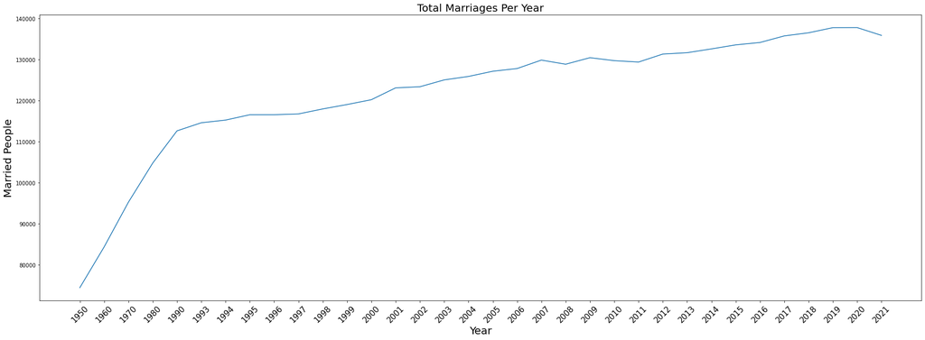

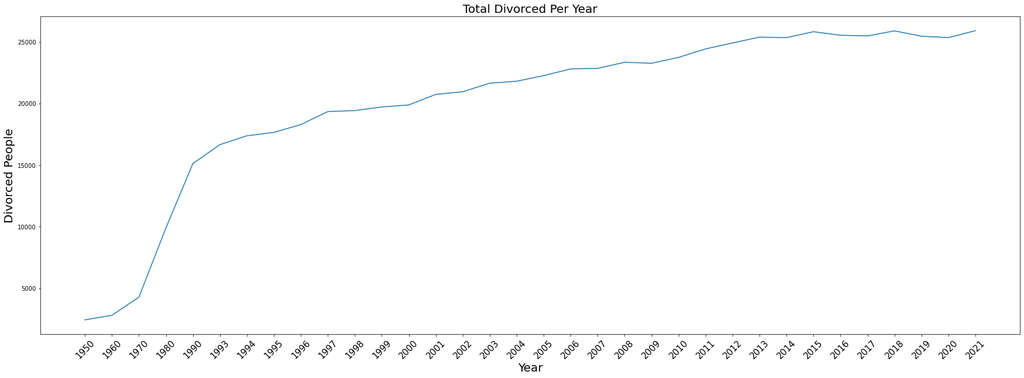

```python
# Set figure size
plt.rcParams['figure.figsize'] = (30, 10)

# Create plot
plot = sns.lineplot(x = 'Year', y = 'Total Married', data=df_divorce)
plot.set_title('Total Marriages Per Year', fontsize=20)
plt.xticks(rotation=45, fontsize=15)

# Setting Axis
plt.ylabel('Married People' , fontsize=20)
plt.xlabel('Year', fontsize=20)

# first graph
plt.show()

# Setting Divorced graph
plt.rcParams['figure.figsize'] = (30, 10)

# Create plot
divorced = sns.lineplot(x = 'Year', y = 'Total Divorced', data=df_divorce)
divorced.set_title('Total Divorced Per Year', fontsize=20)
plt.xticks(rotation=45, fontsize=15)

# Setting Axis
plt.ylabel('Divorced People' , fontsize=20)
plt.xlabel('Year', fontsize=20)

plt.show()
 # seconde graph
plt.rcParams['figure.figsize'] = (30, 10)
```

We can see a significant increase in both which shows that both the amount of married people and the amount of divorced people increased over the course of the years. Now we calculate the percentage of divorced people from the amount of married people.

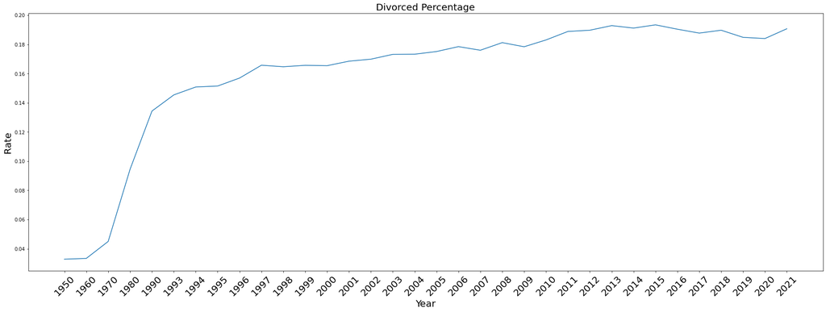

```python
# Set figure size
plt.rcParams['figure.figsize'] = (30, 10)

# Create plot
divpercent = sns.lineplot(x = 'Year', y = 'Divorce/Married', data=df_divorce)

# Set plot title
divpercent.set_title('Divorced Percentage', fontsize=20)

# Rotate ticks so they are legible
plt.xticks(rotation=45, fontsize=20)

# Set Axis titles
plt.ylabel('Rate' , fontsize=20)
plt.xlabel('Year', fontsize=20)

plt.show()
```

### Household Income

The first thing we want to do as part of our EDA is to plot a histogram showing the distribution of the data in the household income dataset.

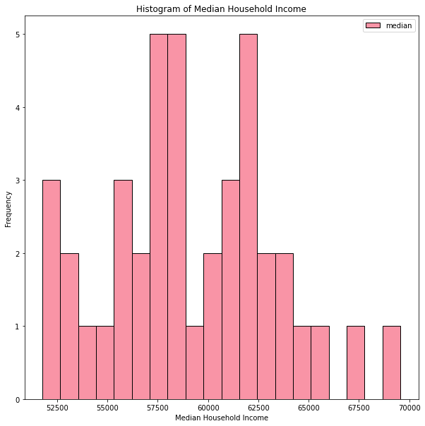

```python
# Set figure size
plt.rcParams['figure.figsize'] = (10, 10)

# Create histplot and set title
sns.histplot(data=df_income, bins = 20, palette='husl').set_title("Histogram of Median Household Income")

plt.xlabel("Median Household Income")
plt.ylabel("Frequency")
```

This histogram gives us the distribution of the median household incomes between 1980 and 2020. From examining this graph, we can see that the most frequent median incomes are in the \$57,000 - \$59,000 and \$61,500 - \$62,500 ranges. The data is slightly skewed to the right, but it is not skewed enough to consider the distribution not normal. There are no significant outliers, but there is one data point that is farther right than the others.

```python
# get the data point that is furthest right
df_income.max()
```

```
Year         2020
median    69560.0
dtype: object
```

Next, we want to do a lineplot to see how the median household income changes over the years.

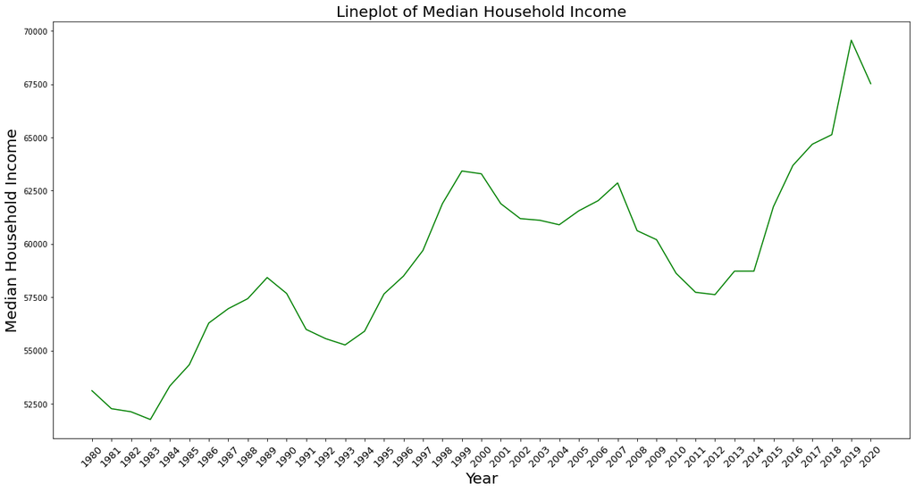

```python
# Set figure size
plt.rcParams['figure.figsize'] = (20, 10)

# Create plot
fig2 = sns.lineplot(x = 'Year', y = 'median', data=df_income, color = 'green')

# Set plot title
fig2.set_title('Lineplot of Median Household Income', fontsize=20)

# Rotate ticks so they are legible
plt.xticks(rotation=45, fontsize=13)

# Set Axis titles
plt.ylabel('Median Household Income', fontsize=20)
plt.xlabel('Year', fontsize=20)

plt.show()
```

From this line plot, we can see that overall, median household income is in an increasing trend. There are a few dips around 1990, 2000, and 2008 that result in the median income declining for a few years, but the income then continues to increase after these declines, likely because the economy is recovering. The 2008 dip is the biggest, probably because the recesssion occurred then, and it took until around 2014 for the household income to start increasing again. The peak income is in 2019 and then declines in 2020, which makes sense because COVID started in 2020.

Next, to observe the relationship between household income and divorce, we will plot a dual axis line plot to show how the data compares.

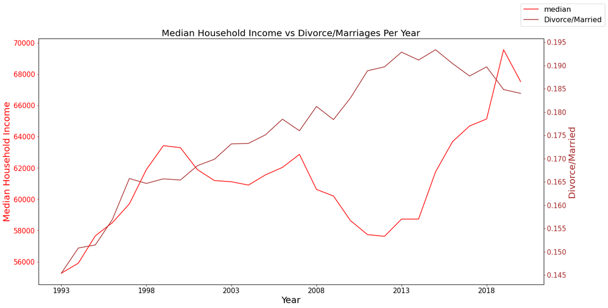

```python
# First, I create a new frame from the divorce frame that only contains year and ratio
div_frame = df_divorce[['Year', 'Divorce/Married']]

# The household income set contains values from years not present in the divorce set, so I remove them
inc_frame = df_income[13:].reset_index(drop=True)

# The divorce frame contains 10 year averages at the top that are not relevant and also contains 2021 which is not in income
# So remove them
div_frame = div_frame[5:-1].reset_index(drop=True)





# Creating a new frame that contains median, Year, and Divorce/Married
# Selecting the median column from inc_frame
col = inc_frame["median"]

# joining the column into div_frame, and copying it to div_inc_frame
div_inc_frame = div_frame.join(col)
div_inc_frame = div_inc_frame[['Year', 'median', 'Divorce/Married']].copy()

# Now for the plotting
# We need a plot with 2 Y axis labels.
# First I create a new plot for median household income and year
ax = div_inc_frame.plot(x="Year", y="median", color = "red", legend=False, fontsize=15)

# Edit labels and set tickmarks
plt.locator_params(axis='both', nbins=15)
plt.xlabel('Year', fontsize=20)
plt.ylabel('Median Household Income', fontsize=20, color = "red")

# Creating the second plot containing the Divorce/Married Data
ax2 = ax.twinx()
ax.tick_params(axis='y', colors='red')
ax2.tick_params(axis='y', colors='brown')

# Combining these into one plot
div_inc_frame.plot(x="Year", y="Divorce/Married", ax=ax2, legend=False, color="brown", fontsize=15)
ax.figure.legend(prop={'size': 16})

# Setting bins and labels
plt.locator_params(axis='both', nbins=15)
plt.ylabel('Divorce/Married', fontsize=20, color = "brown")

# Setting Axis title
plt.title("Median Household Income vs Divorce/Marriages Per Year", fontsize=20)

plt.show()
```

At the earlier years, the divorce rate and household income grow at about the same rate. However, while the household income declines around 2000, the divorce rate continues to increase with just a little bit of variability before finally starting to decline around 2016. In the years around 2013 there is a big gap between divorce rate and household income, but eventually the income catches up with the divorce rate at around 2019. Because of the big dip in household income, it is hard to tell just from this graph if there truly is a correlation between divorce rate and household income.

### Unemployment Rate

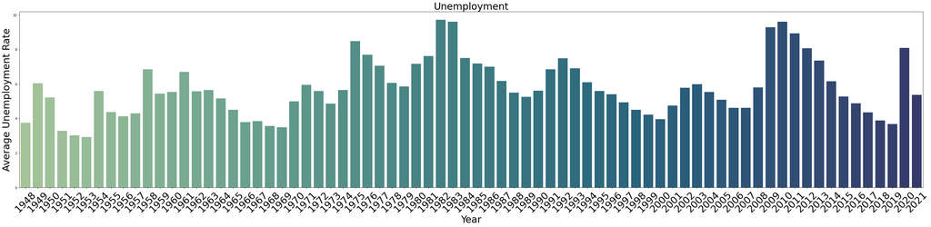

```python
# Set figure size
plt.rcParams['figure.figsize'] = (50, 10)

# Create barplot and set title
#sns.barplot(x = 'avg',y = 'Year',data= df_unemployment, palette='crest', orient = 'h').set_title("Unemployment",fontsize = 30)
sns.barplot(x = 'Year',y = 'avg',data= df_unemployment, palette='crest').set_title("Unemployment",fontsize = 30)

# Rotate ticks so they are legible
plt.xticks(rotation = 45, fontsize = 30)

# Set labels and font size
plt.xlabel("Year", fontsize = 30)
plt.ylabel("Average Unemployment Rate",fontsize = 30)
```

The bar chart above shows the annual unemployment rate from 1948 to 2021, among which no outliers are detected. It is clear that unemployment rate showed no specific skewness, but rather other factors are influencing the changes in unemployment rate.

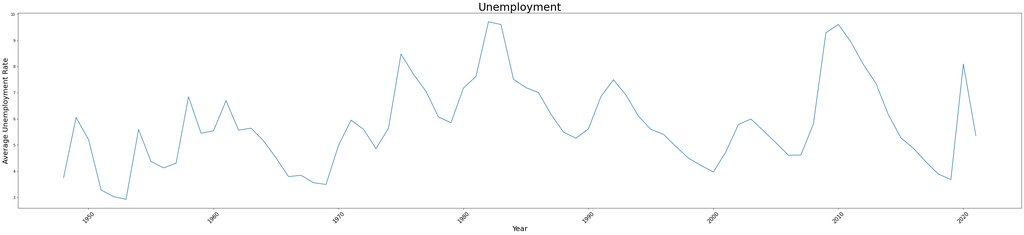

```python
# Set figure size
plt.rcParams['figure.figsize'] = (50, 10)

# Create lineplot and set title
sns.lineplot(x = 'Year',y = 'avg',data= df_unemployment, palette='crest').set_title("Unemployment",fontsize = 30)

# Rotate ticks so they are legible
plt.xticks(rotation = 45, fontsize = 15)

# Set labels and font size
plt.xlabel("Year", fontsize = 20)
plt.ylabel("Average Unemployment Rate",fontsize = 20)
```

Following the line chart, we can see that following each economic recession, a rise in unemployment rate follows, 1900, 2008 and 2020 due to COVID 19. Started in 1990, the major economic boom led to approximately ten years of decline in the unemployment rate due to economic growth and globalization.

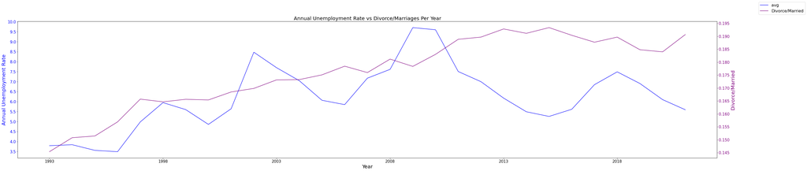

```python
# First, I create a new frame from the divorce frame that only contains year and ratio
div_frame = df_divorce[['Year', 'Divorce/Married']]


# The household debt frame contains values beyond the divorce rate. First, I cut off the extra values.
h_unemployment_frame = df_unemployment.iloc[13:]

# Then I reset the index
h_unemployment_frame = h_unemployment_frame.reset_index()

# The divorce frame contains 10 year averages at the top. I remove these here since they aren't relevant for this graph
div_frame = div_frame.iloc[5:]

# Assign to new frame
div_unemployment_frame = div_frame




# Creating a new frame that contains TDSP, Year, and Divorce/Married
# Selecting the TDSP column from h_debt_frame
col = h_unemployment_frame["avg"]

# joining the column into div_frame, and copying it to div_debt_frame
div_unemployment_frame = div_frame.join(col)
div_unemployment_frame = div_unemployment_frame[['Year', 'avg', 'Divorce/Married']].copy()


# Now for the plotting
# We need a plot with 2 Y axis labels.
# First I create a new plot for TDSP and year
ax = div_unemployment_frame.plot(x="Year", y="avg", color = "blue", legend=False, fontsize=15)

# Edit labels and set tickmarks
plt.locator_params(axis='both', nbins=15)
plt.xlabel('Year', fontsize=20)
plt.ylabel('Annual Unemployment Rate', fontsize=20, color = "blue")

# Creating the second plot containing the Divorce/Married Data
ax2 = ax.twinx()
ax.tick_params(axis='y', colors='blue')
ax2.tick_params(axis='y', colors='purple')

# Combining these into one plot
div_unemployment_frame.plot(x="Year", y="Divorce/Married", ax=ax2, legend=False, color="purple", fontsize=15)
ax.figure.legend(prop={'size': 16})

# Setting bins and labels
plt.locator_params(axis='both', nbins=15)
plt.ylabel('Divorce/Married', fontsize=20, color = "purple")

# Setting Axis title
plt.title("Annual Unemployment Rate vs Divorce/Marriages Per Year", fontsize=20)

plt.show()
```

### Household Debt

#### Household Debt is calculated as TDSP, which is the ratio of total required household debt payments to total disposable income. This calculation takes quarterly mortgage payments and divides by total quarterly disposable personal income. This helps us understand the real costs of mortages, and how it changes over time.

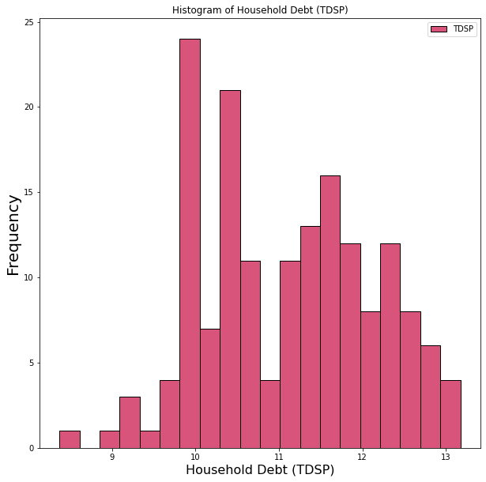

```python
# Set figure size
plt.rcParams['figure.figsize'] = (10, 10)
# Create plot and Set title
sns.histplot(data=df_householddebt, bins = 20, palette = 'rocket').set_title('Histogram of Household Debt (TDSP)')

# Set labels and font size
plt.ylabel('Frequency', fontsize=20)
plt.xlabel('Household Debt (TDSP)', fontsize=16)
```

This histogram gives an overview of the distribution of Household Debt since 1980. It shows that TDSP tends to hower between 10 and 12. The data appears to be bimodal as there are two distinct humps to the curve, with a dip around the 11 mark. It also apprears the chart may have a slight leftwards skew. There are no significant outliers.

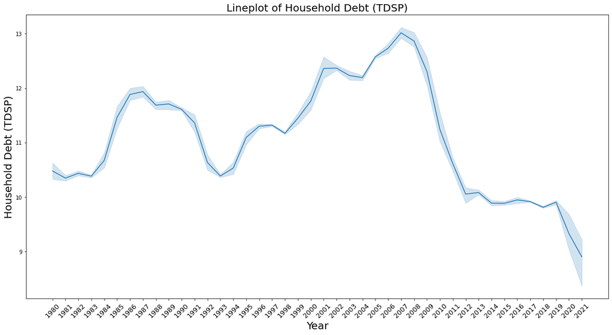

```python
# Set figure size
plt.rcParams['figure.figsize'] = (20, 10)

# Create plot
mattsplot = sns.lineplot(x = 'Year', y = 'TDSP', data=df_householddebt, palette = 'mako')

# Set plot title
mattsplot.set_title('Lineplot of Household Debt (TDSP)', fontsize=20)

# Rotate ticks so they are legible
plt.xticks(rotation=45, fontsize=13)

# Set Axis titles
plt.ylabel('Household Debt (TDSP)' , fontsize=20)
plt.xlabel('Year', fontsize=20)

plt.show()
```

This plot gives an overview of how Household Debt (Calculated as TDSP) has changed since 1980. This graph shows that TDSP fluctuated significantly until the 2000s where it began to generally dramatically. Since the 08' recession it has been on a strong decline to the lowest levels in 40 years. This graph shows that there are no significant outliers.

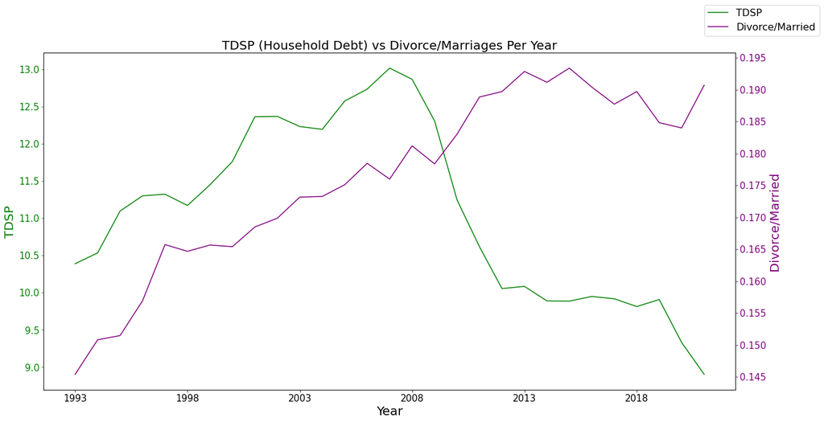

```python
# First, I create a new frame from the divorce frame that only contains year and ratio
div_frame = df_divorce[['Year', 'Divorce/Married']]


# The household debt frame contains values beyond the divorce rate. First, I cut off the extra values.
h_debt_frame = df_householddebt_yearly.iloc[13:]

# Then I reset the index
h_debt_frame = h_debt_frame.reset_index()

# The divorce frame contains 10 year averages at the top. I remove these here since they aren't relevant for this graph
div_frame = div_frame.iloc[5:]
div_frame = div_frame.reset_index()

# Assign to new frame
div_debt_frame = div_frame



# Creating a new frame that contains TDSP, Year, and Divorce/Married
# Selecting the TDSP column from h_debt_frame
col = h_debt_frame["TDSP"]

# joining the column into div_frame, and copying it to div_debt_frame
div_debt_frame = div_frame.join(col)
div_debt_frame = div_debt_frame[['Year', 'TDSP', 'Divorce/Married']].copy()


# Now for the plotting
# We need a plot with 2 Y axis labels.
# First I create a new plot for TDSP and year
ax = div_debt_frame.plot(x="Year", y="TDSP", color = "green", legend=False, fontsize=15)

# Edit labels and set tickmarks
plt.locator_params(axis='both', nbins=15)
plt.xlabel('Year', fontsize=20)
plt.ylabel('TDSP', fontsize=20, color = "green")

# Creating the second plot containing the Divorce/Married Data
ax2 = ax.twinx()
ax.tick_params(axis='y', colors='green')
ax2.tick_params(axis='y', colors='purple')

# Combining these into one plot
div_debt_frame.plot(x="Year", y="Divorce/Married", ax=ax2, legend=False, color="purple", fontsize=15)
ax.figure.legend(prop={'size': 16})

# Setting bins and labels
plt.locator_params(axis='both', nbins=15)
plt.ylabel('Divorce/Married', fontsize=20, color = "purple")

# Setting Axis title
plt.title("TDSP (Household Debt) vs Divorce/Marriages Per Year", fontsize=20)

plt.show()
```

This dual axis line plot compares the changes to Divorce/Marriage to changes in TDSP. The data indicates that Divorce/Married increased with TDSP until the 2008 recession. After the 2008 recession, Divorce/Married continues to increase, wheras TDSP continues to decrease. Based on this graph, it is clear the variables don't necessarily move in the same directions at the same times, though there **is** evidence that both variables tend to change with the similar volatilities. When TDSP rapidly decreased after 08, Divorce/Married rapidly increased, which is seen again in 2020 during the economic turmoil of the Coronavirus pandemic.

### Divorce Rate and Unemployment 1950-2020

Our divorce data as well as our unemployment data has values that start in 1950s. We would like to make additionaly analysis and compare divorce rates and the unemployment rate over a longer period of time and see if there is any correlation and imporvment to our analysis

```python
# To make data columns into an integers
def to_int(str_in):
    output = int(str_in)
    return output
```

```python
# Changing divorce and unemployment year data to integers
df_divorce['Year'] = df_divorce['Year'].apply(to_int)
df_unemployment['Year'] = df_unemployment['Year'].apply(to_int)
```

```python
# Creating a devorce rate data that only includes years with 10 year intervals
df_divorce_10 = df_divorce[((df_divorce['Year'])%10)==0]
df_divorce_10
```

|  | Year | Total Married | Total Divorced | Divorce/Married |
| --- | --- | --- | --- | --- |
| 0 | 1950 | 74443 | 2444 | 0.032830 |
| 1 | 1960 | 84364 | 2814 | 0.033355 |
| 2 | 1970 | 95257 | 4284 | 0.044973 |
| 3 | 1980 | 104778 | 9896 | 0.094447 |
| 4 | 1990 | 112630 | 15128 | 0.134316 |
| 12 | 2000 | 120211 | 19881 | 0.165384 |
| 22 | 2010 | 129722 | 23741 | 0.183014 |
| 33 | 2020 | 137772 | 25348 | 0.183985 |

```python
# Creating an unemployment data starting in 1950 and ending in 2020, just like our divorce data
df_unemployment_10 = df_unemployment.iloc[2:73]
df_unemployment_10
```

|  | Year | avg |
| --- | --- | --- |
| 2 | 1950 | 5.208333 |
| 3 | 1951 | 3.283333 |
| 4 | 1952 | 3.025000 |
| 5 | 1953 | 2.925000 |
| 6 | 1954 | 5.591667 |
| ... | ... | ... |
| 68 | 2016 | 4.875000 |
| 69 | 2017 | 4.358333 |
| 70 | 2018 | 3.891667 |
| 71 | 2019 | 3.675000 |
| 72 | 2020 | 8.091667 |

71 rows × 2 columns

##### Now we plot the divorce data and the unemployment data since 1950 till 2020

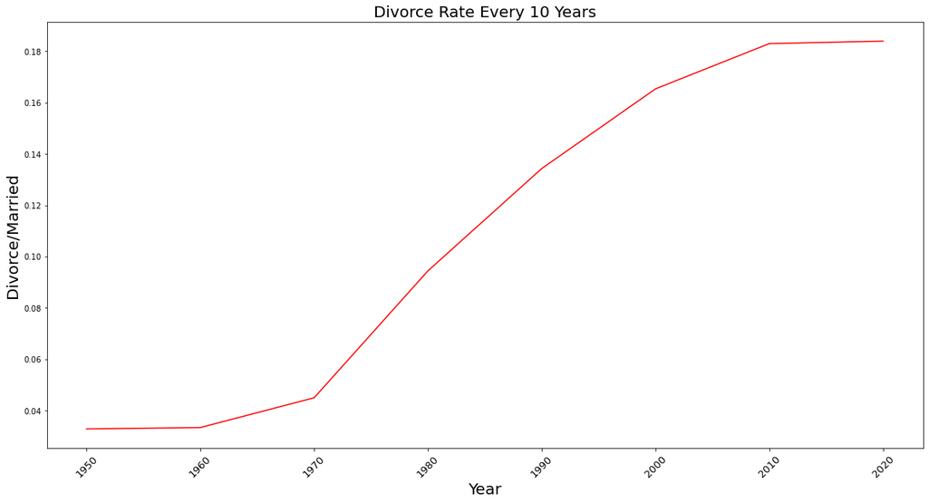

```python
# Set figure size
plt.rcParams['figure.figsize'] = (20, 10)

# Create plot
fig2 = sns.lineplot(x = 'Year', y = 'Divorce/Married', data=df_divorce_10, color = 'red')

# Set plot title
fig2.set_title('Divorce Rate Every 10 Years', fontsize=20)

# Rotate ticks so they are legible
plt.xticks(rotation=45, fontsize=13)

# Set Axis titles
plt.ylabel('Divorce/Married', fontsize=20)
plt.xlabel('Year', fontsize=20)

plt.show()
```

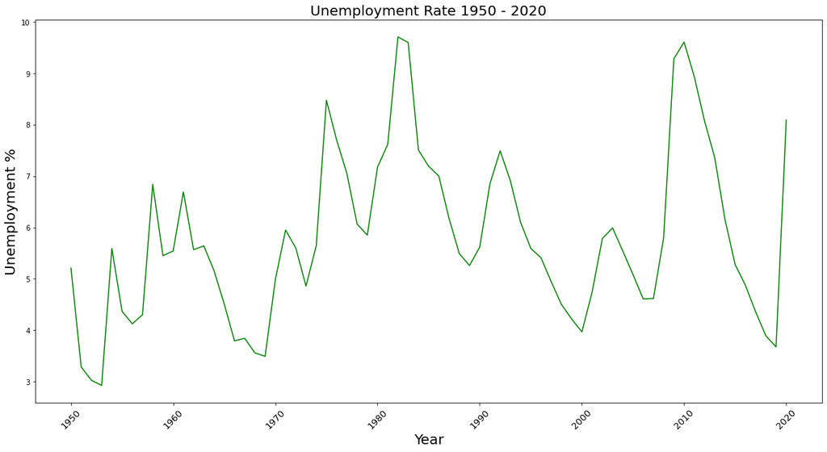

```python
# Set figure size
plt.rcParams['figure.figsize'] = (20, 10)

# Create plot
fig2 = sns.lineplot(x = 'Year', y = 'avg', data=df_unemployment_10, color = 'green')

# Set plot title
fig2.set_title('Unemployment Rate 1950 - 2020', fontsize=20)

# Rotate ticks so they are legible
plt.xticks(rotation=45, fontsize=13)

# Set Axis titles
plt.ylabel('Unemployment %', fontsize=20)
plt.xlabel('Year', fontsize=20)

plt.show()
```

So far the graphs look very different. The divorce rate is constantly increasing every 10 years, while the unemployment rate seems to change constantly. However, we will plot these two graphs together, to help us visualize these two datas together better.

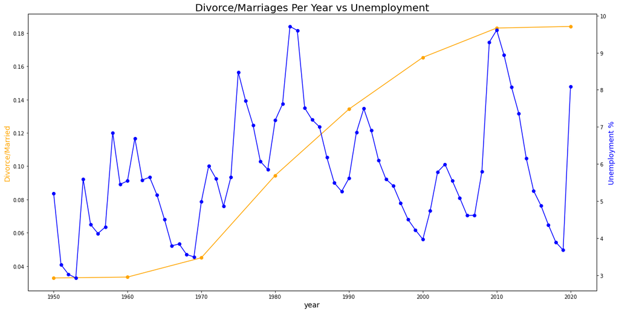

```python
# create figure and axis objects with subplots()
fig,ax = plt.subplots()
# make a plot
ax.plot(df_divorce_10['Year'], df_divorce_10['Divorce/Married'], color="orange", marker="o")
# set x-axis label
ax.set_xlabel("year",fontsize=14)
# set y-axis label
ax.set_ylabel("Divorce/Married",color="orange",fontsize=14)

# twin object for two different y-axis on the sample plot
ax2=ax.twinx()
# make a plot with different y-axis using second axis object
ax2.plot(df_unemployment_10['Year'], df_unemployment_10['avg'],color="blue",marker="o")
ax2.set_ylabel("Unemployment %",color="blue",fontsize=14)
plt.title("Divorce/Marriages Per Year vs Unemployment", fontsize=20)
plt.show()
```

## Regression Analysis

We will use linear regression to check if there is a relationship between each of our variables and the divorce rate. Our null hypothesis is that there is no relationship between the variable and divorce rate and our alternate hypothesis is that there is a relationship between the variable and divorce rate. If we can get a p-value that is small (less than 0.05), then we can reject the null hypothesis and conclude that there is a significant correlation between the variable and divorce rate.

### Household Income

First, we want to plot a regression line graph to see if the relationship between median household income and divorce rate is approximately linear. This tells us if we can use linear regression or not.

```python
# div_inc_frame is a dataframe that contains both median income and divorce rate that was used in EDA
div_inc_frame.columns = ['year', 'median', 'divorce_rate']
```

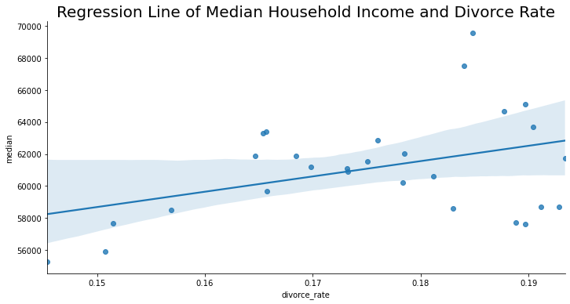

```python
sns.lmplot(x="divorce_rate",
          y="median",
          data=div_inc_frame,
          aspect=2)
plt.title("Regression Line of Median Household Income and Divorce Rate", fontsize=20)
```

```python
# coefficient values seem kinda weird? but not sure what to do to fix it
outcome,predictors = patsy.dmatrices('median ~ divorce_rate', div_inc_frame)
mod = sm.OLS(outcome, predictors)
res = mod.fit()
print(res.summary())
```

```
                            OLS Regression Results
==============================================================================
Dep. Variable:                 median   R-squared:                       0.160
Model:                            OLS   Adj. R-squared:                  0.127
Method:                 Least Squares   F-statistic:                     4.941
Date:                Tue, 08 Mar 2022   Prob (F-statistic):             0.0351
Time:                        03:06:17   Log-Likelihood:                -263.35
No. Observations:                  28   AIC:                             530.7
Df Residuals:                      26   BIC:                             533.4
Df Model:                           1
Covariance Type:            nonrobust
================================================================================
                   coef    std err          t      P>|t|      [0.025      0.975]
--------------------------------------------------------------------------------
Intercept     4.434e+04   7578.101      5.851      0.000    2.88e+04    5.99e+04
divorce_rate  9.568e+04    4.3e+04      2.223      0.035    7204.053    1.84e+05
==============================================================================
Omnibus:                        1.273   Durbin-Watson:                   0.299
Prob(Omnibus):                  0.529   Jarque-Bera (JB):                0.725
Skew:                           0.394   Prob(JB):                        0.696
Kurtosis:                       3.016   Cond. No.                         76.9
==============================================================================

Notes:
[1] Standard Errors assume that the covariance matrix of the errors is correctly specified.
```

Since we get a p-value = 0.035 < 0.05, we can reject the null hypothesis and conclude that there is indeed a positive relationship between median household income and divorce rate.

## Divorce and Unemployment since 1993

Data Cleaning

```python
df_divorce= div_frame
df_divorce.columns = ['index','Year','Divorce']
#trim unemployment rate to start with 1993 matching with divorce data
df_temp = df_unemployment.iloc[45:]
#reset index after trimming
df_temp = df_temp.reset_index()
#extract unemployment rate
unp = df_temp['avg']
df_all = df_divorce.join(unp)
df_all = df_all.drop(['index'], axis=1)
#create a new dataframe contain year, Divorce, and unemployment rate
#df_all = pd.concat([df_divorce, df_temp], axis=1)
df_all
```

|  | Year | Divorce | avg |
| --- | --- | --- | --- |
| 0 | 1993 | 0.145383 | 6.908333 |
| 1 | 1994 | 0.150790 | 6.100000 |
| 2 | 1995 | 0.151458 | 5.591667 |
| 3 | 1996 | 0.156905 | 5.408333 |
| 4 | 1997 | 0.165710 | 4.941667 |
| 5 | 1998 | 0.164658 | 4.500000 |
| 6 | 1999 | 0.165642 | 4.216667 |
| 7 | 2000 | 0.165384 | 3.966667 |
| 8 | 2001 | 0.168467 | 4.741667 |
| 9 | 2002 | 0.169847 | 5.783333 |
| 10 | 2003 | 0.173145 | 5.991667 |
| 11 | 2004 | 0.173252 | 5.541667 |
| 12 | 2005 | 0.175088 | 5.083333 |
| 13 | 2006 | 0.178445 | 4.608333 |
| 14 | 2007 | 0.175969 | 4.616667 |
| 15 | 2008 | 0.181180 | 5.800000 |
| 16 | 2009 | 0.178357 | 9.283333 |
| 17 | 2010 | 0.183014 | 9.608333 |
| 18 | 2011 | 0.188838 | 8.933333 |
| 19 | 2012 | 0.189682 | 8.075000 |
| 20 | 2013 | 0.192836 | 7.358333 |
| 21 | 2014 | 0.191145 | 6.158333 |
| 22 | 2015 | 0.193360 | 5.275000 |
| 23 | 2016 | 0.190384 | 4.875000 |
| 24 | 2017 | 0.187714 | 4.358333 |
| 25 | 2018 | 0.189684 | 3.891667 |
| 26 | 2019 | 0.184810 | 3.675000 |
| 27 | 2020 | 0.183985 | 8.091667 |
| 28 | 2021 | 0.190683 | 5.358333 |

Regression

```python
outcome,predictors = patsy.dmatrices('Divorce ~ avg',df_all)
mod_log = sm.OLS(outcome,predictors)
res_log = mod_log.fit()
print(res_log.summary())
```

```
                            OLS Regression Results
==============================================================================
Dep. Variable:                Divorce   R-squared:                       0.026
Model:                            OLS   Adj. R-squared:                 -0.010
Method:                 Least Squares   F-statistic:                    0.7314
Date:                Tue, 08 Mar 2022   Prob (F-statistic):              0.400
Time:                        03:06:17   Log-Likelihood:                 84.189
No. Observations:                  29   AIC:                            -164.4
Df Residuals:                      27   BIC:                            -161.6
Df Model:                           1
Covariance Type:            nonrobust
==============================================================================
                 coef    std err          t      P>|t|      [0.025      0.975]
------------------------------------------------------------------------------
Intercept      0.1682      0.010     17.578      0.000       0.149       0.188
avg            0.0014      0.002      0.855      0.400      -0.002       0.005
==============================================================================
Omnibus:                        2.580   Durbin-Watson:                   0.111
Prob(Omnibus):                  0.275   Jarque-Bera (JB):                2.145
Skew:                          -0.652   Prob(JB):                        0.342
Kurtosis:                       2.723   Cond. No.                         23.2
==============================================================================

Notes:
[1] Standard Errors assume that the covariance matrix of the errors is correctly specified.
```

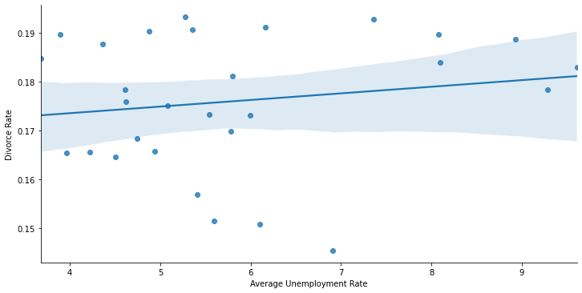

```python
sns.lmplot(x = 'avg',
           y = 'Divorce',
           data  = df_all,
          aspect = 2)

plt.xlabel('Average Unemployment Rate')
plt.ylabel('Divorce Rate')
```

# Household Debt vs Divorce Regression Analysis

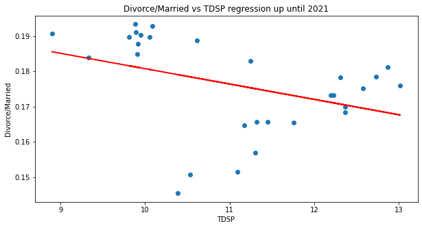

OLS Regression Results

| Dep. Variable: | DM | R-squared: | 0.142 |
| --- | --- | --- | --- |
| Model: | OLS | Adj. R-squared: | 0.110 |
| Method: | Least Squares | F-statistic: | 4.472 |
| Date: | Tue, 08 Mar 2022 | Prob (F-statistic): | 0.0438 |
| Time: | 11:12:53 | Log-Likelihood: | 86.024 |
| No. Observations: | 29 | AIC: | -168.0 |
| Df Residuals: | 27 | BIC: | -165.3 |
| Df Model: | 1 |  |  |
| Covariance Type: | nonrobust |  |  |

|  | coef | std err | t | P>\|t\| | [0.025 | 0.975] |
| --- | --- | --- | --- | --- | --- | --- |
| Intercept | 0.2243 | 0.023 | 9.781 | 0.000 | 0.177 | 0.271 |
| TDSP | -0.0044 | 0.002 | -2.115 | 0.044 | -0.009 | -0.000 |

| Omnibus: | 9.219 | Durbin-Watson: | 0.089 |
| --- | --- | --- | --- |
| Prob(Omnibus): | 0.010 | Jarque-Bera (JB): | 7.997 |
| Skew: | -1.251 | Prob(JB): | 0.0183 |
| Kurtosis: | 3.597 | Cond. No. | 107. |

Notes:  
[1] Standard Errors assume that the covariance matrix of the errors is correctly specified.

```python
import statsmodels.formula.api as sm

# I'll be using statsmodels to preform this linear regression
# First, I rename the columns
div_debt_frame = div_debt_frame.rename(columns={'TDSP': 'TDSP', 'Divorce/Married': 'DM'})

# Initialise and fit linear regression model using statsmodels
div_debt_model = sm.ols('DM ~ TDSP', data=div_debt_frame)
div_debt_model = div_debt_model.fit()

# Predict values
# Predict using the model we just created
tdsp_div_reg = div_debt_model.predict()

# Create a plot for our data and regression line
plt.figure(figsize=(10, 5))

# regression line
plt.plot(div_debt_frame['TDSP'], div_debt_frame['DM'], 'o')
# scatter plot showing actual data
plt.plot(div_debt_frame['TDSP'], tdsp_div_reg, linewidth=2, color='r')

#Set graph labels and titles
plt.xlabel('TDSP')
plt.ylabel('Divorce/Married')
plt.title('Divorce/Married vs TDSP regression up until 2021')

#Display graph
plt.show()

#Display model summary stats
div_debt_model.summary()
```

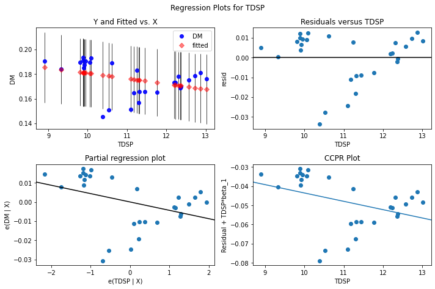

```python
import statsmodels.api as sm2
fig= plt.figure(figsize=(10, 6.66))
fig = sm2.graphics.plot_regress_exog(div_debt_model, 'TDSP', fig=fig)
```

### Result

Null hypothesis = no correlation between TDSP and DM up until 2021

Alternate hypothesos = TDSP and DM are correlated up until 2021

**What is clear is that this is a very poor model, here is why:**

- low R squared value shows our regression line is poor
- T value is bigger for our intercept than for TDSP, further evidence our regression is poor
- F stat is small and the difference between adjusted F stat and F stat is not particuarly big
- residuals are not normally distributed

### Discussion

The model created above clearly does not do a good job at modeling the relationship between the two variables, and this can be attributed to the way TDSP decreased after 2008. After 2009, the economy was relanaced and the measure of household debt decreased. What this points to is that economic turmoils can cause radically changes that literally 'break' certain variables. Because TDSP is calcualted as the total required household debt payments to total disposable income, rebalancing after the recession either caused total disposable income to increase dramatically, or household debt payments changed radically. Given the 2009 recession's ties to subprime mortrages, it is likely that the household debt payments changed substantially.

For this reason, it may be intersting to understand how TDSP and Divorce/Married were correlated before this economic turmoil dramatically changed TDSP. Below, I remove the rows after 2009, and do a second regression on the data before 2009.

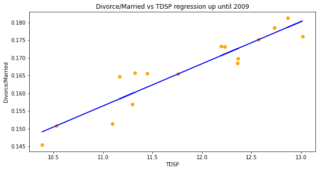

OLS Regression Results

| Dep. Variable: | DM | R-squared: | 0.873 |
| --- | --- | --- | --- |
| Model: | OLS | Adj. R-squared: | 0.864 |
| Method: | Least Squares | F-statistic: | 95.94 |
| Date: | Tue, 08 Mar 2022 | Prob (F-statistic): | 1.21e-07 |
| Time: | 11:13:13 | Log-Likelihood: | 67.254 |
| No. Observations: | 16 | AIC: | -130.5 |
| Df Residuals: | 14 | BIC: | -129.0 |
| Df Model: | 1 |  |  |
| Covariance Type: | nonrobust |  |  |

|  | coef | std err | t | P>\|t\| | [0.025 | 0.975] |
| --- | --- | --- | --- | --- | --- | --- |
| Intercept | 0.0256 | 0.014 | 1.780 | 0.097 | -0.005 | 0.057 |
| TDSP | 0.0119 | 0.001 | 9.795 | 0.000 | 0.009 | 0.014 |

| Omnibus: | 1.450 | Durbin-Watson: | 1.381 |
| --- | --- | --- | --- |
| Prob(Omnibus): | 0.484 | Jarque-Bera (JB): | 0.842 |
| Skew: | 0.039 | Prob(JB): | 0.657 |
| Kurtosis: | 1.879 | Cond. No. | 178. |

Notes:  
[1] Standard Errors assume that the covariance matrix of the errors is correctly specified.

```python
# I'll be using statsmodels to preform this linear regression
# First, I rename the columns
div_debt_frame2 = div_debt_frame.iloc[0:16]


# Initialise and fit linear regression model using statsmodels
div_debt_model2 = sm.ols('DM ~ TDSP', data=div_debt_frame2)
div_debt_model2 = div_debt_model2.fit()

# Predict values
# Predict using the model we just created
tdsp_div_reg2 = div_debt_model2.predict()

# Create a plot for our data and regression line
plt.figure(figsize=(10, 5))

# regression line
plt.plot(div_debt_frame2['TDSP'], div_debt_frame2['DM'], 'o', color='orange')
# scatter plot showing actual data
plt.plot(div_debt_frame2['TDSP'], tdsp_div_reg2, linewidth=2, color='b')

#Set graph labels and titles
plt.xlabel('TDSP')
plt.ylabel('Divorce/Married')
plt.title('Divorce/Married vs TDSP regression up until 2009')

#Display graph
plt.show()

#Display model summary stats
div_debt_model2.summary()
```

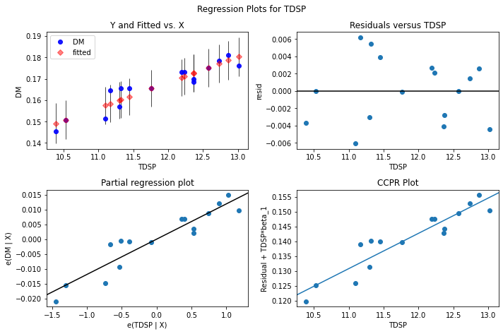

```python
fig= plt.figure(figsize=(10,6.66))
fig = sm2.graphics.plot_regress_exog(div_debt_model2, 'TDSP', fig=fig)
```

### Result up until 2009

This second regression on the data up till 2008 shows we have a much better model and the two variables are correlated.

Null hypothesis = no correlation up until 2008

Alternate hypothesis = they are correlated up to 2008

**This is a better model, here is why:**

Result: **Strong correlation.** P is smaller than alpha so we reject the null hypothesis. **87.3%** of the variance in Divorce/Married corresponds to variance in TDSP.

### Discussion

Overall, it seems that TDSP and Divorce/Married were strongly correlated before the 2009 recession, indicated by our second model. During the rebalancing period after the 2009 recession, it seems that changes were made to mortages, and TDSP no longer correlates, as indicated by our first model.

*~end TDSP regression*

# Ethics & Privacy

# Conclusion & Discussion

# Team Contributions